# 02-cs01-intro

Author

Affiliation

Professor Shannon Ellis

Published

October 4, 2024

# CS01: Biomarkers of Recent Use

## Q&A

> Q: Does R let you perform arithmetic across number and integer types?  
> A: Yup! For example `7L + 2` gives you 9. (Similarly `7L + 2.2` gives 9.2)

> Q: I am confused on how to open up projects, what it means to comit and pull.  
> A: We’ll review this again today!

> Q: I am very new to using Github, so using Github is a bit confusing, but probably just b/c I am very new to it.  
> A: This is a normal feeling at the start of this course! I promise in a week it will feel more comfortable!

> Q: I’m curious about the usage of R versus Python. Are there certain situations where R is more useful than Python?  
> A: In a nutshell, *almost* everything you can do in one you can do in the other. However, in my opinion, R is most useful when 1) cleaning data, 2) using statistical models, and 3) visualizing data. (On the flip side, when I’m writing software, using APIs, and gathering data, I typically turn to Python.)

> Q: How do I save my lecture practice into a new file in R?  
> A: I would recommend opening a new .Rmd file and then saving it with the name of the lecture.

> Q: i noticed that global variables remain in the environment panel even when i delete that variable in my rmd script. does it matter that they are still there? i tried clicking the broom and rerunning the code, and only the variables i wanted remained, but is this the right way to go about changing or deleting variables in my code?  
> A: Yup! The broom will clean up your environment! There is also an `rm()` function if you ever want to remove an individual variable from your environment.

> Q: Am I supposed to create an “R Markdown” or an “R Notebook”?  
> A: I’ll demo R Markdown, so encouraging use of that.

> Q: Will we be covering any syntax guidelines when programming in R? For example, in other programming languages indents/spaces are necessary for many functions but I’m wondering if there is anything like that used in R.  
> A: I will highlight them as we go! R does not necessitate whitespace ever, but stylistically, we will encourage it. What I teach will be based off of this [style guide](https://style.tidyverse.org/).

> Q: How many points are there in total for the extra credits  
> A: I’m not totally sure yet. At least a few points.

> Q: I wonder what will be the format of the lab session?  
> A: Typically a short presentation (5 min) at the beginning to explain the lab or discuss the most difficult/confusing part. Then, time to work on lab and get questions answered by staff.

> Q: Could you please post the slides one or two days before class? I would like to review them in advance so I can better follow along during the lecture and not feel lost. A: I totally understand the request, and I’ll do my best! (For example, these have been up since Monday), but I’m re-doing the slides up to class many days. While the examples will change this quarter, the concepts will overlap with last Fall, so feel free to reference [those notes](https://cogs137.github.io/website/).

> Q: What are the main parts of the R interface that we will be interacting with?  
> A: RMarkdown files, R Console, Git pane, Files pane, and Plots pane

> Q: I had a question about the survey for participation. I’m usually busy right after class. Is there any way to get credit for it even if I submit it a couple of hours later or for it to open a little before class ends.  
> A: I do typically end class a few minutes early for completion then and we’re working to open it a few minutes before class ends. It’s always fine to fill it out later if it’s open. It will always be open until at least 5PM.

## Course Announcements

**Due Dates**:

- Student survey due Fri 10/4 (11:59 PM; #finaid)
- **Lab 01** now available (due *next* Thursday 10/10)
  - No in-class lab this Friday; *Monday’s lab is happening*
- Lecture Participation survey “due” after class

Note:

- Run this in console once: `options(download.file.method="wget")`
- We’re going to *start* CS01 in lecture/lab before you know your group mates.
- Reminder to Shannon: demo lab clone, push pull

## Agenda

- Background
- Data Intro
- Paper Results
- Wrangle

# Background

## Case Studies in COGS 137

- Question + Data Provided
- Wrangling + Analysis Discussed/Presented in Class
- In groups:
  - reproduce the analysis
  - extend the analysis

## Deliverables

- Full qmd report (explanations, text and story matter!)
- General Audience communication

## CS01: Biomarkers of Recent Use

- Focuses on Data Wrangling and EDA
- Uses real research data from a collaboration w/ Rob Fitgerald’s group

## Motor Vehicle Accidents (MVAs)

- 2/3 of US trauma center admissions are due to MVAs
- ~60% of such patients testing positive for drugs or alcohol
- Alcohol and cannabis are most frequently detected

Source: https://academic.oup.com/clinchem/article/59/3/478/5621997

## Legalization of Marijuana

- Federally illegal in the US
- Decriminalized in many states
- Medically available in 15 states
- Legal for recreational use in 24 states (including CA)

## Increased roadside surveys

- 25% increase in use nationwide from 2002 to 2015 ([survey](https://rosap.ntl.bts.gov/view/dot/1913))
- THC detection in drivers increased by 48% from 2007 to 2014
- Increased prevalence of consumption -> possible intoxication -> possible impaired driving -> public health concern

## DUI of Alcohol (DUIA)

- The science is there. Don’t do it.
- DUIA has decreased since the 1970s
  - % of nighttime, weekend drivers testing over the legal limit (BAC > 0.08 g/dL) decreased from 7.5% (1973) to 2.2% (2007) link

## DUI of Cannabis

- In a 2007 survey, 16.3% of nighttime drivers were drug-positive [link](https://rosap.ntl.bts.gov/view/dot/1913)
  - 8.6% of these tested positive for THC
- Experimental and cognitive studies suggest cannabis-induced impairment increases risk of motor vehicle crashes:

. . .

> Evidence suggests recent smoking and/or blood THC concentrations 2–5 ng/mL are associated with substantial driving impairment, particularly in occasional smokers.[link](https://academic.oup.com/clinchem/article/59/3/478/5621997)

## Roadside Detection

- *per se* laws: “a driver is deemed to have committed an offense if THC is detected at or above a pre-determined cutoff” [link](https://doi.org/10.1080/15389588.2020.1851685)

. . .

- Defining cutoffs for safe driving is difficult
- THC concentration differs by:
  - “smoking topography” (time to smoke; number of puffs)
  - frequency of use
  - route of ingestion

. . .

As of 2021…[link](https://www.tandfonline.com/doi/full/10.1080/15389588.2020.1851685)

- 19 states have *per se* or zero tolerance cannabis laws
- States with *per se* laws (Illinois, Montana, Nevada, Ohio, Pennsylvania, Washington and West Virginia), cutoffs range from 1 to 5 ng/mL THC in whole blood.
- In 3 states, *per se* limits also apply to THC metabolites
- Colorado: “reasonable inference” - blood contained >5 ng/mL THC at the time of the offense
- 3 states zero tolerance for THC; 8 states for THC and metabolites

## Metabolism

- peak blood concentrations occur during smoking, then drop rapidly [link](https://academic.oup.com/jat/article/36/6/405/791790)
- subjective ‘high’ persists for several hours, varies greatly between individuals
- THC concentrations remain detectable in frequent users longer than occasional users [link](https://academic.oup.com/clinchem/article/59/3/519/5622035)
- THC and certain metabolites can be detected in blood for weeks to months after use and do not necessarily indicate impairment

## Detection

Various approaches:

1. Detect impairment (officers detect DUIC)
2. Detect recent use (test for compounds)
3. Combine recent use + impairment

. . .

**Focus here**: Can we identify a biomarker of recent use?

- recent use: defined here as within 3h
- testing THC and metabolites in blood, oral fluid (OF), and breath

## Aside: Case Study Report

- Your Case study will need a background section
- It can use/summarize/paraphrase the information here (you should cite the source, not me)
- But, you’re *not* limited to this information
- You are allowed/encouraged to dig deeper, include what’s most important, add to, remove, etc.
- There are a lot of citations in this section - go ahead and peruse them/others/use references in these papers

# Question

Which compound, in which matrix, and at what cutoff is the best biomarker of recent use?

# The Data

## Participants

- placebo-controlled, double-blinded, randomized study

. . .

- recruited:
  - volunteers 21-55 y/o
  - had a driver’s license
  - self-reported cannabis use >= 4x in the past month

. . .

- Participants were:
  - compensated
  - medically evaluated (for safety)
  - asked to refrain from use for 2d prior to participation
  - exclusion criteria: OF THC concentration ≥5 ng/mL on day of study (n=7)

. . .

- Study included 191 participants

## Demographics

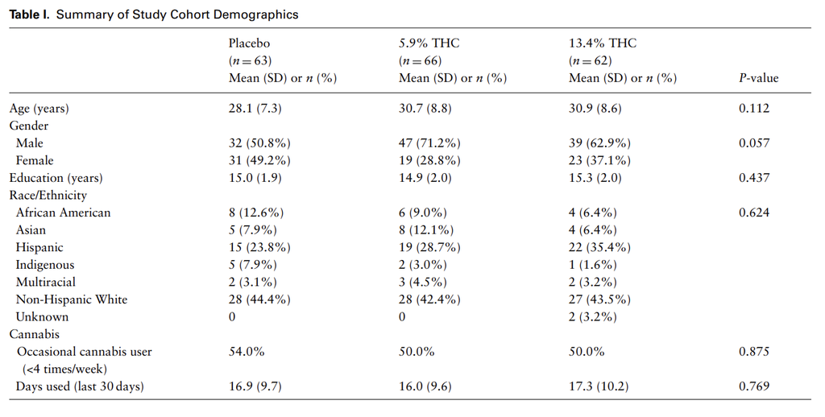

Source: [Hoffman et al.](https://academic.oup.com/jat/article/45/8/851/6309824?login=false)

## Experimental Design

Participants were:

- randomly assigned to receive a cigarette containing placebo (0.02%), or 5.9% or 13.4% THC
- Blood, OF and breath were collected prior to smoking
- smoked a 700 mg cigarette *ad libitum* within 10 min, with a minimum of four puffs.
- After smoking, 4 additional OF and breath and 8 blood collections were completed at time points up to ∼6h from the start of smoking.
- Participants ate and drank water between collections, although not within 10 min of OF collection.

## Timeline

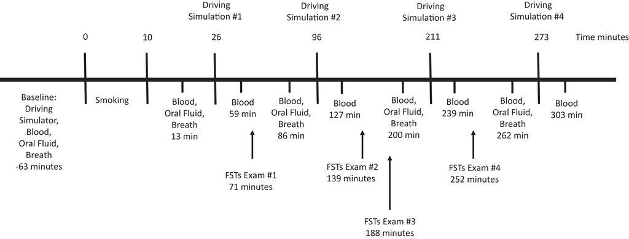

Source: [Fitzgerald et al.](https://academic.oup.com/clinchem/article/69/7/724/7179849?login=false)

## Consumption

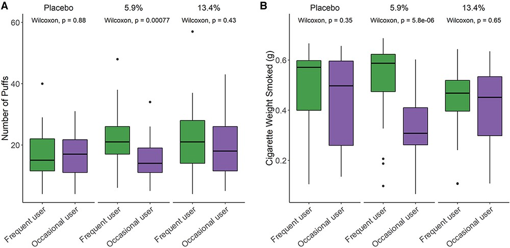

Source: [Hoffman et al.](https://academic.oup.com/jat/article/45/8/851/6309824?login=false)

## Topography

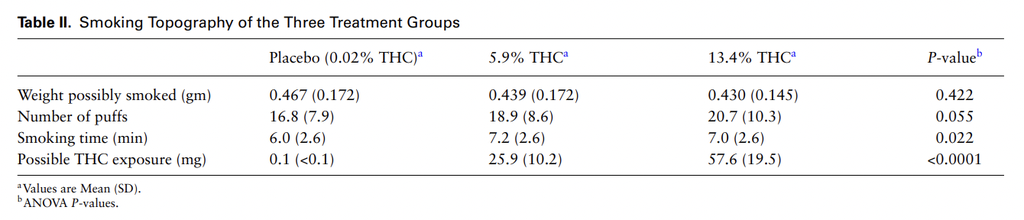

Source: [Hoffman et al.](https://academic.oup.com/jat/article/45/8/851/6309824?login=false)

## What do we recall?

- Summarize what we know about Detection of Impairment for DUIC.
- Summarize what experiment was carried out.
- Summarize what we know about the data so far.

## Subjective Highness

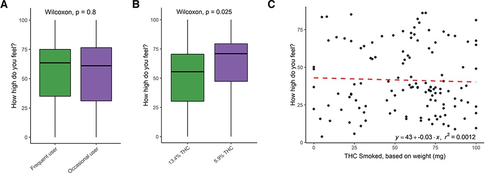

Source: [Hoffman et al.](https://academic.oup.com/jat/article/45/8/851/6309824?login=false)

## Our Datasets

Three matrices:

- Blood (WB): 8 compounds; 190 participants
- Oral Fluid (OF): 7 compounds; 192 participants
- Breath (BR): 1 compound; 191 participants

. . .

Variables:

- `ID` | participants identifier
- `Treatment` | placebo, 5.90%, 13.40%
- `Group` | Occasional user, Frequent user
- `Timepoint` | indicator of which point in the timeline participant’s collection occurred
- `time.from.start` | number of minutes from consumption
- & measurements for individual compounds

## The Data

You’ll have access once your groups/repos are created…(today I want people to follow along; there will be time to try on your own soon!)

**Important**

These data are for our use only and not to be shared widely, so this case study cannot be put in your portfolio, but CS02 and your final project can!

```r
WB <- read_csv("data/Blood.csv")
BR <- read_csv("data/Breath.csv")
OF <- read_csv("data/OF.csv")
```

## First Look at the data (WB)

|  | ID | Treatment | Group | FLUID TYPE | Timepoint | CBN | CBD | THC | 11-OH-THC | THC-COOH | THC-COOH-Gluc | CBG | THC-V | time.from.start |
| --- | --- | --- | --- | --- | --- | --- | --- | --- | --- | --- | --- | --- | --- | --- |
| 1 | 11255 | 5.90% | Occasional user | WB | T1 | 0 | 0 | 0.5 | 0 | 5.7 | 4.9 | 0 | 0 | -27 |
| 2 | 11255 | 5.90% | Occasional user | WB | T2A | 2.8 | 0 | 32.4 | 5.4 | 13.5 | 4.4 | 1.2 | 0 | 15 |
| 3 | 11255 | 5.90% | Occasional user | WB | T2B | 0.6 | 0 | 5.1 | 2.4 | 11.7 | 6.2 | 0 | 0 | 69 |
| 4 | 11255 | 5.90% | Occasional user | WB | T3A | 0 | 0 | 3.2 | 1.8 | 9.7 | 8.4 | 0 | 0 | 111 |
| 5 | 11255 | 5.90% | Occasional user | WB | T3B | 0 | 0 | 1.8 | 1.4 | 8.7 | 8.9 | 0 | 0 | 156 |
| 6 | 11255 | 5.90% | Occasional user | WB | T4A | 0 | 0 | 1.2 | 0 | 6.7 | 8.2 | 0 | 0 | 236 |
| 7 | 11255 | 5.90% | Occasional user | WB | T4B | 0 | 0 | 0.9 | 0 | 6.8 | 7.5 | 0 | 0 | 283 |
| 8 | 11255 | 5.90% | Occasional user | WB | T5A | 0 | 0 | 0.8 | 0 | 6.8 | 7.1 | 0 | 0 | 315 |
| 9 | 11255 | 5.90% | Occasional user | WB | T5B | 0 | 0 | 0.6 | 0 | 6.3 | 6.1 | 0 | 0 | 360 |
| 10 | T0686 | 5.90% | Frequent user | WB | T1 | 0 | 0 | 0 | 0 | 1.9 | 2.1 | 0 | 0 | -10 |

[output cut: 1515 more lines]

## First Look at the data (OF)

|  | ID | Treatment | Group | Fluid | Timepoint | CBN | CBD | THC | 11-OH-THC | CBG | THC-V | THCA-A | time.from.start |
| --- | --- | --- | --- | --- | --- | --- | --- | --- | --- | --- | --- | --- | --- |
| 1 | 11255 | 5.90% | Not experienced user | OF | T1 | 0 | 0 | 0 | 0 | 0 | 0 | 0 | -29 |
| 2 | 11255 | 5.90% | Not experienced user | OF | T2A | 87.7 | 2.8 | 721.5 | 0 | 45.7 | 5.3 | 14.3 | 23 |
| 3 | 11255 | 5.90% | Not experienced user | OF | T3A | 4.2 | 0 | 31.2 | 0 | 1.9 | 0 | 1.1 | 103 |
| 4 | 11255 | 5.90% | Not experienced user | OF | T4A | 0.7 | 0 | 6.2 | 0 | 0 | 0 | 0 | 249 |
| 5 | 11255 | 5.90% | Not experienced user | OF | T5A | 0.6 | 0 | 4.8 | 0 | 0 | 0 | 0 | 315 |
| 6 | T0686 | 5.90% | Experienced user | OF | T1 | 0 | 0 | 0 | 0 | 0 | 0 | 0 | -8 |
| 7 | T0686 | 5.90% | Experienced user | OF | T2A | 22.9 | 0.5 | 142.4 | 0 | 7.6 | 1.2 | 56.5 | 23 |
| 8 | T0686 | 5.90% | Experienced user | OF | T3A | 1.4 | 0 | 9.7 | 0 | 0 | 0 | 1.3 | 111 |
| 9 | T0686 | 5.90% | Experienced user | OF | T4A | 0 | 0 | 0.5 | 0 | 0 | 0 | 0 | 222 |
| 10 | T0686 | 5.90% | Experienced user | OF | T5A | 0 | 0 | 0.6 | 0 | 0 | 0 | 0 | 285 |

[output cut: 943 more lines]

## First Look at the data (BR)

|  | ID | Treatment | Group | Fluid | Timepoint | THC (pg/pad) | time.from.start |
| --- | --- | --- | --- | --- | --- | --- | --- |
| 1 | 11255 | 5.90% | Not experienced user | BR | T1 | 0 | -26 |
| 2 | 11255 | 5.90% | Not experienced user | BR | T2A | 32637.2 | 22 |
| 3 | 11255 | 5.90% | Not experienced user | BR | T3A | 0 | 117 |
| 4 | 11255 | 5.90% | Not experienced user | BR | T4A | 0 | 251 |
| 5 | 11255 | 5.90% | Not experienced user | BR | T5A | 0 | 316 |
| 6 | T0686 | 5.90% | Experienced user | BR | T1 | 0 | -2 |
| 7 | T0686 | 5.90% | Experienced user | BR | T2A | 54861.3 | 24 |
| 8 | T0686 | 5.90% | Experienced user | BR | T3A | 1254.5 | 112 |
| 9 | T0686 | 5.90% | Experienced user | BR | T4A | 0 | 224 |
| 10 | T0686 | 5.90% | Experienced user | BR | T5A | 263.1 | 286 |

[output cut: 939 more lines]

# Analysis

Where We’re Headed…

Results from: Hubbard et al (2021) Biomarkers of Recent Cannabis Use in Blood, Oral Fluid and Breath [link](https://academic.oup.com/jat/article/45/8/820/6311388?login=false#303593274)

## Fig 1: Pre-smoking

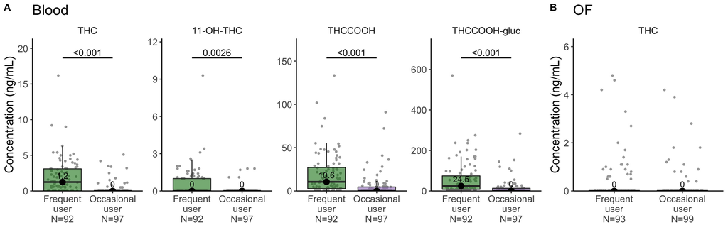

## Fig 2: Sensitivity and Specificity

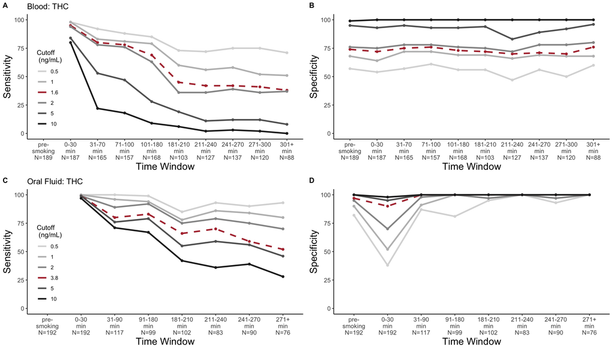

## Fig 3: Cross-compound relationship

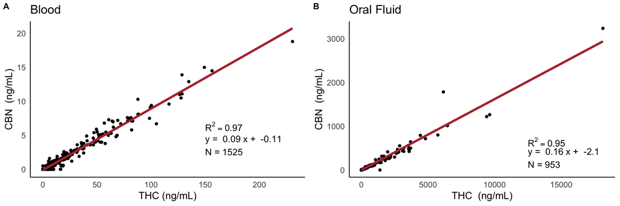

## Fig 4: Cutoffs

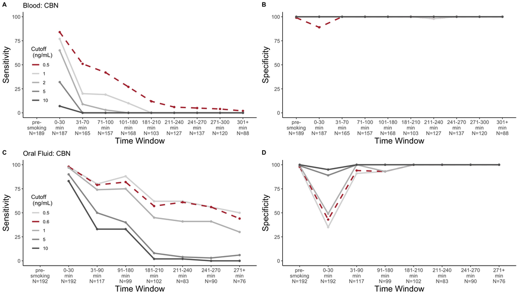

## Fig 5: Youden

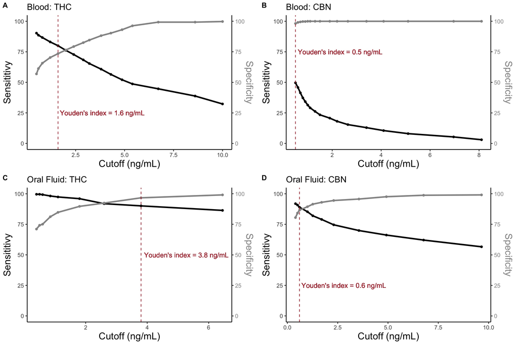

. . .

…and if there’s time PPV and Accuracy post 3h

## What Came After

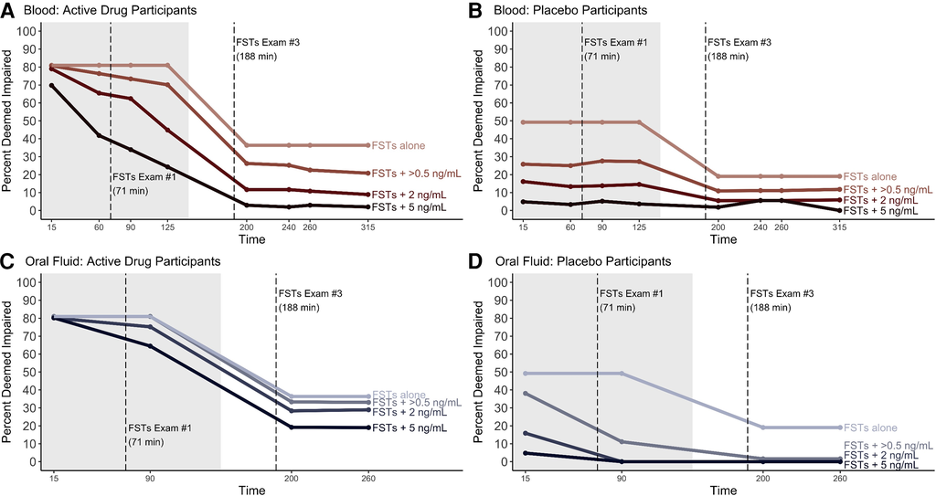

Source: [Fiztgerald et al.](https://academic.oup.com/clinchem/article/69/7/724/7179849?login=false)

## Recap

- Could you summarize/explain background presented?
- Could you summarize the experiment that was done?
- Could you describe the datasets? (variables, observations, values, etc.)